# Logistic Regression

Marc Los Huertos

EA030 · Compiled 2026-04-14

EA030 — Advanced Statistics — Module 09

# Logistic Regression

**Prof. Marc Los Huertos** • Pomona College

← Back to RTricks

Why Logistic? The Model Fitting in R Reading Output Odds Ratios Predictions Diagnostics ROC & AUC

By the end of this module you will be able to

1. Explain why ordinary regression fails for binary outcomes and what logistic regression does instead.
2. Fit `glm(…, family = binomial)` in R and interpret model output.
3. Convert log-odds to odds ratios and to predicted probabilities.
4. Evaluate model fit with AIC, the null deviance, and a confusion matrix.
5. Visualise a logistic curve over the observed data.

> **What this module covers.** When your outcome is binary — present/absent, exceeded/not exceeded, survived/died — ordinary linear regression fails because it can predict probabilities outside [0, 1]. Logistic regression solves this by modeling the *log-odds* of the outcome, producing well-calibrated probabilities and interpretable odds ratios. This tutorial covers the full workflow: fitting with `glm()`, interpreting coefficients as odds ratios, assessing model fit, and evaluating predictive performance with ROC curves.

## 1. Why Not Just Use Linear Regression?

Suppose you want to predict whether a river site exceeds a pollution threshold (1 = exceeds, 0 = does not) based on upstream land-use intensity. If you fit a straight line through 0s and 1s, two problems arise immediately:

1. **Out-of-range predictions.** A line can predict probabilities below 0 or above 1, which are nonsensical.
2. **Non-constant variance.** The variance of a binary outcome is $p(1-p)$, which changes with p — violating the homoscedasticity assumption of linear regression.

Logistic regression maps the linear predictor to a probability using the **logistic (sigmoid) function**, guaranteeing predictions in (0, 1).

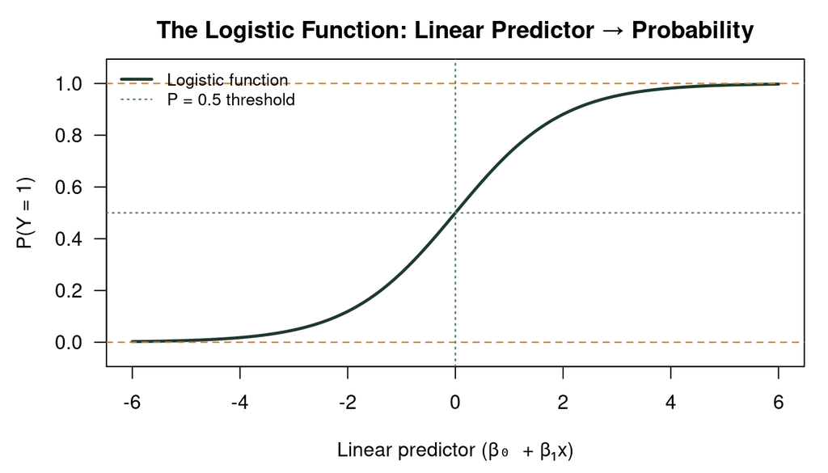

The logistic (sigmoid) function maps any real-valued linear predictor to a probability between 0 and 1. The S-shape reflects how the response to increasing x is strongest in the middle of the probability range.

## 2. The Logistic Regression Model

The model links the probability of the outcome p to predictors through the **logit** (log-odds) transformation:

$$\log\left(\frac{p}{1-p}\right) = \beta_0
+ \beta_1 x_1 + \cdots + \beta_k x_k$$

Solving for p:

$$p = \frac{1}{1 + e^{-(\beta_0 + \beta_1
x)}} = \text{logistic}(\beta_0 + \beta_1 x)$$

The coefficients $\beta$ are estimated by **maximum likelihood** (not least squares). The log-likelihood measures how well the model’s predicted probabilities match the observed 0/1 outcomes.

**Key relationships**

- **Log-odds (logit):** log(p / (1-p)) — ranges from −∞ to +∞
- **Odds:** p / (1-p) — ranges from 0 to +∞
- **Probability:** p = logistic(log-odds) — ranges from 0 to 1
- **Odds ratio (OR):** exp(β) — the multiplicative change in odds per unit increase in x

## 3. Fitting Logistic Regression in R

```r
library(MASS)
data(birthwt)

# Recode for clarity
bw <- birthwt |>
  mutate(
    low     = factor(low,   labels = c("Normal", "Low")),
    smoke   = factor(smoke, labels = c("Non-smoker", "Smoker")),
    race    = factor(race,  labels = c("White", "Black", "Other")),
    ht      = factor(ht,    labels = c("No hypertension", "Hypertension")),
    low_bin = as.integer(low == "Low")   # keep numeric version for glm
  )

table(bw$low)
```

```
##
## Normal    Low
##    130     59
```

### Explore predictors first

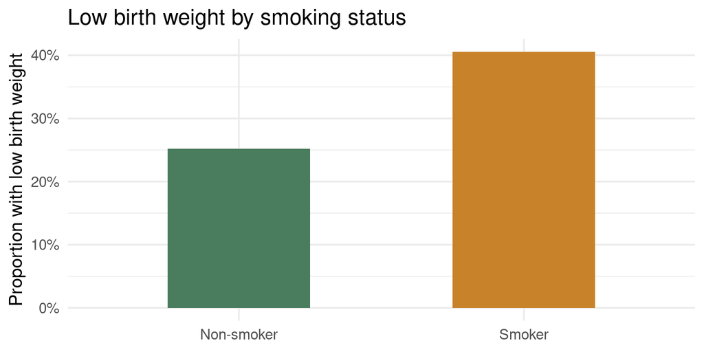

Birth weight by maternal smoking status. Low birth weight is more common among smokers — consistent with the known physiological pathway.

```r
bw |>
  count(smoke, low) |>
  group_by(smoke) |>
  mutate(pct = n / sum(n)) |>
  filter(low == "Low") |>
  ggplot(aes(x = smoke, y = pct, fill = smoke)) +
  geom_col(width = 0.5) +
  scale_fill_manual(values = c("#4a7c5e", "#c8832a")) +
  scale_y_continuous(labels = scales::percent) +
  labs(x = NULL, y = "Proportion with low birth weight",
       title = "Low birth weight by smoking status") +
  theme_minimal(base_size = 13) +
  theme(legend.position = "none")
```

### Fit the model

```r
mod_logit <- glm(low_bin ~ smoke + age + lwt + race + ht,
                 data   = bw,
                 family = binomial(link = "logit"))
```

The key argument is `family = binomial(link = "logit")`. This tells `glm()` that: (1) the outcome is binary (Bernoulli distribution), and (2) the link function is the logit, connecting the linear predictor to the probability.

## 4. Reading `summary()` Output

```r
summary(mod_logit)
```

```
##
## Call:
## glm(formula = low_bin ~ smoke + age + lwt + race + ht, family = binomial(link = "logit"),
##     data = bw)
##
## Coefficients:
##                 Estimate Std. Error z value Pr(>|z|)
## (Intercept)     0.777274   1.160336   0.670  0.50294
## smokeSmoker     1.064664   0.389159   2.736  0.00622 **
## age            -0.021166   0.034960  -0.605  0.54489
## lwt            -0.017297   0.006866  -2.519  0.01176 *
## raceBlack       1.238728   0.526253   2.354  0.01858 *
## raceOther       0.919052   0.427195   2.151  0.03145 *
## htHypertension  1.732974   0.687931   2.519  0.01177 *
## ---
## Signif. codes:  0 '***' 0.001 '**' 0.01 '*' 0.05 '.' 0.1 ' ' 1
##
## (Dispersion parameter for binomial family taken to be 1)
##
##     Null deviance: 234.67  on 188  degrees of freedom
## Residual deviance: 207.88  on 182  degrees of freedom
## AIC: 221.88
##
## Number of Fisher Scoring iterations: 4
```

The coefficients table has the same columns as `lm()` — Estimate, Std. Error, z value, Pr(>|z|) — but the test statistic is a z-test (Wald test), not a t-test.

**Deviance.** The logistic model uses *deviance* (−2 × log-likelihood) instead of residual sums of squares. The Null deviance is for a model with only an intercept; the Residual deviance is for your model. A substantial drop indicates the predictors explain something.

**AIC.** Akaike Information Criterion = deviance + 2k. Smaller is better; use AIC to compare competing models.

[output not shown]

## 5. Odds Ratios

Odds ratios are the most common effect size for logistic regression. OR > 1 means the predictor increases the odds of the outcome; OR < 1 means it decreases the odds.

```r
# Exponentiate coefficients and confidence intervals
or_table <- exp(cbind(OR = coef(mod_logit), confint(mod_logit)))
round(or_table, 3)
```

```
##                   OR 2.5 % 97.5 %
## (Intercept)    2.176 0.232 22.413
## smokeSmoker    2.900 1.373  6.372
## age            0.979 0.913  1.048
## lwt            0.983 0.969  0.995
## raceBlack      3.451 1.235  9.888
## raceOther      2.507 1.099  5.922
## htHypertension 5.657 1.523 23.882
```

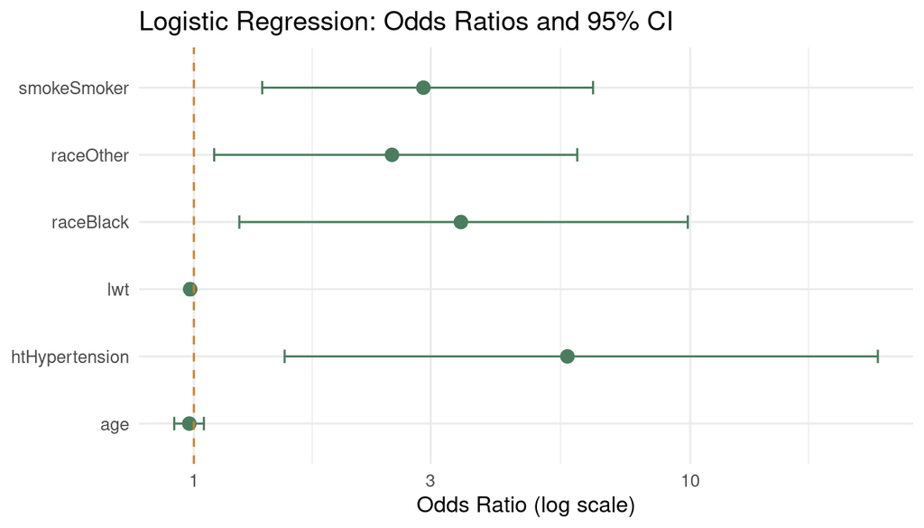

Odds ratio plot with 95% confidence intervals. OR > 1 increases the odds of low birth weight; OR < 1 decreases them. The vertical dashed line at OR = 1 is the null hypothesis of no effect.

```r
or_df <- as.data.frame(or_table[-1, ])   # drop intercept
or_df$term <- rownames(or_df)
names(or_df)[2:3] <- c("ci_lo", "ci_hi")

ggplot(or_df, aes(x = term, y = OR)) +
  geom_point(size = 3, color = "#4a7c5e") +
  geom_errorbar(aes(ymin = ci_lo, ymax = ci_hi),
                width = 0.2, color = "#4a7c5e") +
  geom_hline(yintercept = 1, linetype = "dashed", color = "#c8832a") +
  coord_flip() +
  scale_y_log10() +
  labs(x = NULL, y = "Odds Ratio (log scale)",
       title = "Logistic Regression: Odds Ratios and 95% CI") +
  theme_minimal(base_size = 12)
```

## 6. Predicted Probabilities

Unlike linear regression, logistic regression predictions are probabilities, not raw response values. Use `type = "response"` with `predict()`.

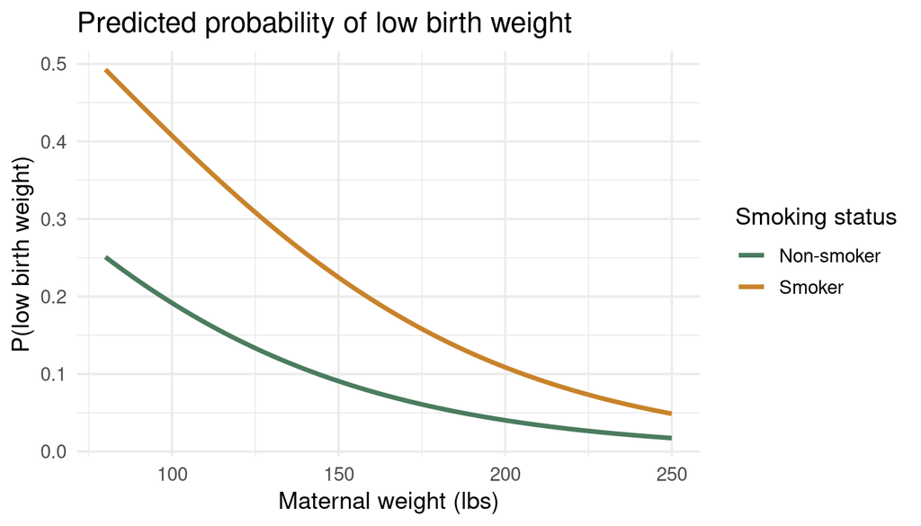

Predicted probability of low birth weight as a function of maternal weight at last menstrual period, holding other predictors at reference levels. Smoking status shifts the curve upward.

```r
# Predictions across maternal weight range, by smoking status
new_data <- expand.grid(
  lwt   = seq(80, 250, by = 2),
  smoke = factor(c("Non-smoker", "Smoker"), levels = levels(bw$smoke)),
  age   = median(bw$age),
  race  = "White",
  ht    = "No hypertension"
)
new_data$pred_prob <- predict(mod_logit, newdata = new_data, type = "response")

ggplot(new_data, aes(x = lwt, y = pred_prob, color = smoke)) +
  geom_line(linewidth = 1.2) +
  scale_color_manual(values = c("#4a7c5e", "#c8832a")) +
  labs(x = "Maternal weight (lbs)", y = "P(low birth weight)",
       title = "Predicted probability of low birth weight",
       color = "Smoking status") +
  theme_minimal(base_size = 13)
```

## 7. Model Diagnostics

### Deviance goodness-of-fit

The likelihood ratio test compares your model to the null (intercept-only) model.

```r
mod_null <- glm(low_bin ~ 1, data = bw, family = binomial)
anova(mod_null, mod_logit, test = "Chisq")
```

```
## Analysis of Deviance Table
##
## Model 1: low_bin ~ 1
## Model 2: low_bin ~ smoke + age + lwt + race + ht
##   Resid. Df Resid. Dev Df Deviance  Pr(>Chi)
## 1       188     234.67
## 2       182     207.88  6   26.794 0.0001582 ***
## ---
## Signif. codes:  0 '***' 0.001 '**' 0.01 '*' 0.05 '.' 0.1 ' ' 1
```

### Pseudo-R² (McFadden)

```r
pseudo_r2 <- 1 - logLik(mod_logit) / logLik(mod_null)
```

McFadden pseudo-R² = **0.114**.

McFadden values of 0.2–0.4 indicate good fit; above 0.4 is excellent. This is not directly comparable to OLS R² — it measures relative improvement over the null model.

### Binned residual plot

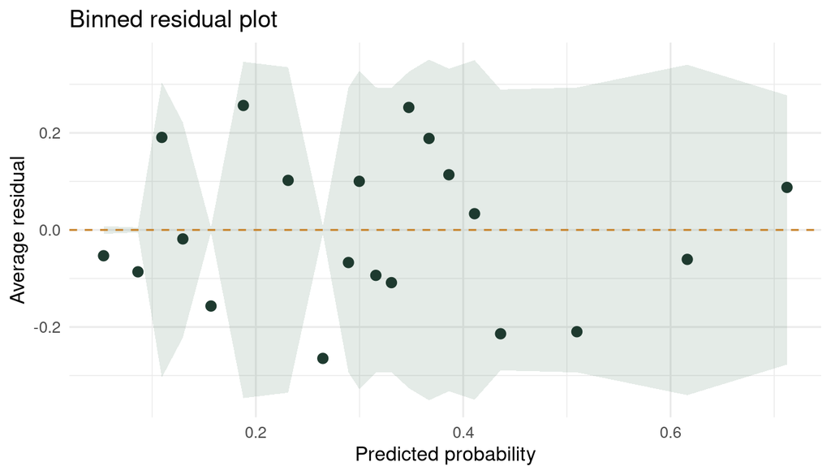

Binned residual plot. Bins within the grey bands (±2 SE) suggest adequate fit. Points outside the bands may indicate model misspecification or influential observations.

```r
# Manual binned residual plot (avoids arm package dependency)
pred   <- predict(mod_logit, type = "response")
resid  <- bw$low_bin - pred
n_bins <- 20
breaks <- quantile(pred, probs = seq(0, 1, length.out = n_bins + 1))
bin_id <- cut(pred, breaks = breaks, include.lowest = TRUE, labels = FALSE)

bin_df <- data.frame(pred, resid, bin_id) |>
  group_by(bin_id) |>
  summarise(mean_pred = mean(pred), mean_resid = mean(resid),
            se = sd(resid) / sqrt(n()), .groups = "drop")

ggplot(bin_df, aes(x = mean_pred, y = mean_resid)) +
  geom_ribbon(aes(ymin = -2 * se, ymax = 2 * se), alpha = 0.15, fill = "#4a7c5e") +
  geom_point(color = "#1e3a2f", size = 2.5) +
  geom_hline(yintercept = 0, linetype = "dashed", color = "#c8832a") +
  labs(x = "Predicted probability", y = "Average residual",
       title = "Binned residual plot") +
  theme_minimal(base_size = 12)
```

## 8. ROC Curve and AUC

The **receiver operating characteristic (ROC) curve** shows how well the model discriminates between the two outcome classes across all possible probability thresholds. The **area under the curve (AUC)** summarizes discrimination in a single number: 0.5 = random guessing; 1.0 = perfect discrimination.

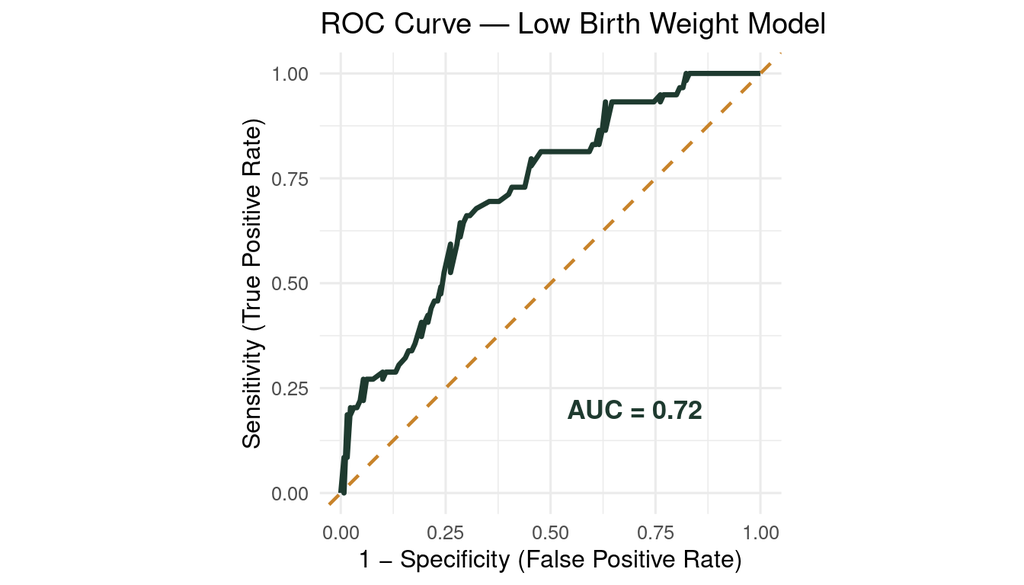

ROC curve for the low birth weight model. AUC > 0.7 indicates acceptable discrimination. The dashed diagonal is a model that guesses randomly (AUC = 0.5).

```r
# Compute sensitivity and specificity at each threshold
thresholds <- seq(0, 1, length.out = 300)
pred_prob  <- predict(mod_logit, type = "response")
obs        <- bw$low_bin

roc_df <- data.frame(
  threshold = thresholds,
  sens = sapply(thresholds, function(t) mean((pred_prob >= t)[obs == 1])),
  spec = sapply(thresholds, function(t) mean((pred_prob <  t)[obs == 0]))
)

# AUC via trapezoidal rule
auc <- abs(sum(diff(1 - roc_df$spec) * roc_df$sens[-nrow(roc_df)]))

ggplot(roc_df, aes(x = 1 - spec, y = sens)) +
  geom_line(color = "#1e3a2f", linewidth = 1.2) +
  geom_abline(slope = 1, intercept = 0, linetype = "dashed",
              color = "#c8832a", linewidth = 0.8) +
  annotate("text", x = 0.7, y = 0.2,
           label = paste0("AUC = ", round(auc, 3)),
           color = "#1e3a2f", size = 4.5, fontface = "bold") +
  labs(x = "1 − Specificity (False Positive Rate)",
       y = "Sensitivity (True Positive Rate)",
       title = "ROC Curve — Low Birth Weight Model") +
  coord_equal() +
  theme_minimal(base_size = 12)
```

### Choosing a classification threshold

The default threshold of 0.5 is not always optimal. A confusion matrix at 0.5 shows the trade-off between sensitivity (catching true positives) and specificity (avoiding false positives).

```r
pred_class <- ifelse(pred_prob >= 0.5, 1, 0)
table(Predicted = pred_class, Observed = obs)
```

```
##          Observed
## Predicted   0   1
##         0 122  43
##         1   8  16
```

**💡 When to adjust the threshold** In public health contexts, false negatives (missing a high-risk case) may be more costly than false positives. Lowering the threshold increases sensitivity at the cost of specificity. The optimal threshold depends on the relative costs of the two error types — a decision that requires domain knowledge, not statistics alone.

#### 🔑 Key takeaways

- Use `glm(y ~ x, family = binomial)` for binary outcomes. Linear regression will produce nonsensical probability predictions for extreme x values.
- Coefficients are on the **log-odds scale**. Always exponentiate with `exp(coef(mod))` to get interpretable **odds ratios**.
- OR > 1 increases the odds; OR < 1 decreases them. An OR of 2 means the odds double for a one-unit increase in x.
- Use `predict(type = “response”)` to get predicted **probabilities**.
- Evaluate discrimination with **AUC**: above 0.7 is acceptable; above 0.8 is good. Check calibration with a binned residual plot.

### What’s next?

- **Survival Analysis** — extend to binary outcomes with a time dimension and censored observations
- **Multiple Regression & GLMs** — count outcomes (Poisson), overdispersion, and model selection

✏️ Practice Exercises

Exercise 1 — Fit and interpret

Using `airquality`, create a binary variable `high_ozone` (TRUE if Ozone > 60 ppb). Fit a logistic regression predicting `high_ozone` from `Temp`. (a) Report the coefficient on Temp as a log-odds and as an odds ratio. (b) What is the predicted probability of a high-ozone day at 90°F?

**Show solution**

```
data(airquality)
airquality$high_ozone <- airquality$Ozone > 60
mod <- glm(high_ozone ~ Temp, data = airquality, family = binomial, na.action = na.omit)
summary(mod)
exp(coef(mod))             # odds ratios
predict(mod, newdata = data.frame(Temp = 90), type = "response")
```

Each 1°F increase in temperature multiplies the odds of a high-ozone day by OR ≈ 1.15. At 90°F, predicted probability ≈ 0.35 (35%).

Tests for Association ↑ Module Index Correlation Analysis